# homework-week-6

# [1] Write a simple R function, Z.prop.test(), that can perform one- or two-sample Z-tests for proportion data.

-Your function should take the following arguments: p1 and n1 (no default) to pose as the estimated proportion and sample size (i.e., based on your sample data); p2 and n2 (both defaulting to NULL) that contain a second sample’s proportion and sample size data in the event of a two-sample test; p0 (no default) as the expected value for the population proportion; and alternative (default “two.sided”) and conf.level (default 0.95), to be used in the same way as in the function t.test(). -When conducting a two-sample test, it should be p1 that is tested as being smaller or larger than p2 when alternative=“less” or alternative=“greater”, the same as in the use of x and y in the function t.test(). -The function should perform a one-sample Z-test using p1, n1, and p0 if either p2 or n2 (or both) is NULL. -The function should contain a check for the rules of thumb we have talked about (n*p>5 and n*(1-p)>5) to ensure the validity of assuming the normal distribution in both the one- and two-sample settings. If this is violated, the function should still complete but it should also print an appropriate warning message. -The function should return a list containing the members Z (the test statistic), P (the appropriate p-value), and CI (the two-sided CI with respect to confidence level).

```r
Z.prop.test<-function(p1,n1,p2=NULL,n2=NULL,p0,alternative="two.sided",conf.level=0.95){ #set up arguments and defaults
  if (if.null(p2)||if.null(n2)){ #set up 1-sample z-test
    if(n1*p1<=5||n1*(1-p1)<=5){ #assess validity of normal dist.
    warning("Oh dear! Normal distribution may not be valid!; np<=5 or n(1-p)<=5") #spit out warning if above rules are violated
  }
    Z<-(p1-p0)/sqrt((p0*(1-p0))/n1) #1-sample z-test, see eq. 18.8
    se_p1<-sqrt(p0*(1-p0)/n1) #write out se to make CI cleaner
    CI<-p1+c(-1*((qnorm(((1-conf.level)/2)+conf.level))*se_p1),
         ((qnorm(((1-conf.level)/2)+conf.level))*se_p1))
    #CI = statistic +/- critical value*standard error
    #statistic = p1
    #critical value = 0.025 and 0.975
    #standard error = see above
  }
  else{ #set up 2-sample Z-test
    if(p1*n1<=5||n1*(1-p1)<=5||p2*n2<=5||n2*(1-p2)<=5){
    warning("Oh dear! Normal distribution may not be valid!; np<=5 or n(1-p)<=5")
  }
    pstar<-((p1*n1)+(p2*n2))/(n1+n2) #pooled proportion
    Z<-(p1-p2-p0)/sqrt(pstar*(1-pstar)*((1/n1)+(1/n2))) #2-sample z-test, see eq. 18.9
    se_pstar<-sqrt((pstar*(1-pstar)*(1/n1+1/n2)))
    CI<-(p1-p2)+c((-1*qnorm(conf.level+(1-conf.level)/2)*se_pstar),qnorm(conf.level+(1-conf.level)/2)*se_pstar)
    #CI = statistic +/- critical value*standard error
    #statistic = p1-p2 (assessing p1 as lesser/greater than p2)
    #critical value = 0.025 and 0.975
    #standard error = see above
  }
#p-values for less, greater, and two-tailed tests:
  if (alternative=="less"){
      p<-pnorm(z,lower.tail=T)
    }
    if (alternative=="greater"){
      p<-pnorm(z,lower.tail=F)
    }
  if (alternative=="two.tailed"){
            if (Z>0) {p<-2*pnorm(z,lower.tail=FALSE)}
            if (Z<0) {p<-2*pnorm(z,lower.tail=TRUE)}
    }
  return(list(Zscore=Z,pvalue=p,CI=CI)) #return list of values
}
```

# [2] The dataset from Kamilar and Cooper has in it a large number of variables related to life history and body size. For this exercise, the end aim is to fit a simple linear regression model to predict longevity (“MaxLongevity_m”) measured in months from species’ brain size (“Brain_Size_Species_Mean”) measured in grams. Do the following for both longevity~brain size and log(longevity)~log(brain size).

-Fit the regression model and, using {ggplot2}, produce a scatterplot with the fitted line superimposed upon the data. Append the the fitted model equation to your plot (HINT: use the function geom_text()). -Identify and interpret the point estimate of the slope beta1, as well as the outcome of the test associated with the hypotheses H0: beta1 = 0; HA:beta1 ≠ 0. Also, find a 90 percent CI for the slope beta1 parameter. -Using your model, add lines for the 90 percent confidence and prediction interval bands on the plot and add a legend to differentiate between the lines. -Produce a point estimate and associated 90 percent PI for the longevity of a species whose brain weight is 800 gm. Do you trust the model to predict observations accurately for this value of the explanatory variable? Why or why not? -Looking at your two models, which do you think is better? Why?

## Step 0: Import data

```r
d<-read.csv(file="/Users/rachelvoyt/Desktop/ADA/KamilarAndCooperData.csv",sep=",",header=T)
head(d)
```

```
##               Scientific_Name          Family          Genus      Species
## 1 Allenopithecus_nigroviridis Cercopithecidae Allenopithecus nigroviridis
## 2         Allocebus_trichotis Cercopithecidae      Allocebus    trichotis
## 3           Alouatta_belzebul        Atelidae       Alouatta     belzebul
## 4             Alouatta_caraya        Atelidae       Alouatta       caraya
## 5            Alouatta_guariba        Atelidae       Alouatta      guariba
## 6           Alouatta_palliata        Atelidae       Alouatta     palliata
##   Brain_Size_Species_Mean Brain_Size_Female_Mean   Brain_size_Ref
## 1                   58.02                  53.70 Isler et al 2008
## 2                      NA                     NA
## 3                   52.84                  51.19 Isler et al 2008
## 4                   52.63                  47.80 Isler et al 2008
## 5                   51.70                  49.08 Isler et al 2008
## 6                   49.88                  48.04 Isler et al 2008
##   Body_mass_male_mean Body_mass_female_mean Mass_Dimorphism
```

[output cut: 69 more lines]

```r
library("ggplot2")
```

## Step 1: Fit the regression model and, using {ggplot2}, produce a scatterplot with the fitted line superimposed upon the data. Append the the fitted model equation to your plot (HINT: use the function geom_text()).

```r
#Renaming variables b/c they're too hard to type
brain_size<-d$Brain_Size_Species_Mean
max_longev<-d$MaxLongevity_m
log_max_longev<-log(max_longev)
log_brain_size<-log(brain_size)

#Regression model - regular
m<-lm(max_longev~brain_size,data=d)
summary(m)
```

```
##
## Call:
## lm(formula = max_longev ~ brain_size, data = d)
##
## Residuals:
##     Min      1Q  Median      3Q     Max
## -198.27  -61.92  -17.78   56.16  331.36
##
## Coefficients:
##             Estimate Std. Error t value Pr(>|t|)
## (Intercept) 248.9523    11.1111   22.41   <2e-16 ***
## brain_size    1.2180     0.1101   11.06   <2e-16 ***
## ---
## Signif. codes:  0 '***' 0.001 '**' 0.01 '*' 0.05 '.' 0.1 ' ' 1
##
## Residual standard error: 90.91 on 126 degrees of freedom
##   (85 observations deleted due to missingness)
## Multiple R-squared:  0.4928, Adjusted R-squared:  0.4887
## F-statistic: 122.4 on 1 and 126 DF,  p-value: < 2.2e-16
```

```r
#Regression model - log transformed
log_m<-lm(data=d,log_max_longev~log_brain_size)
summary(log_m)
```

```
##
## Call:
## lm(formula = log_max_longev ~ log_brain_size, data = d)
##
## Residuals:
##     Min      1Q  Median      3Q     Max
## -0.6955 -0.1750 -0.0097  0.1788  0.6084
##
## Coefficients:
##                Estimate Std. Error t value Pr(>|t|)
## (Intercept)     4.87895    0.06907   70.63   <2e-16 ***
## log_brain_size  0.23415    0.01781   13.15   <2e-16 ***
## ---
## Signif. codes:  0 '***' 0.001 '**' 0.01 '*' 0.05 '.' 0.1 ' ' 1
##
## Residual standard error: 0.2485 on 126 degrees of freedom
##   (85 observations deleted due to missingness)
## Multiple R-squared:  0.5784, Adjusted R-squared:  0.5751
## F-statistic: 172.9 on 1 and 126 DF,  p-value: < 2.2e-16
```

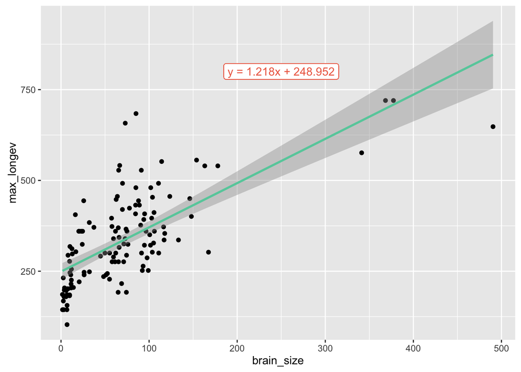

```r
#Scatterplot - regular
p <- ggplot(data=d,aes(x=brain_size, y=max_longev)) + geom_point() + geom_smooth(method="lm",formula=y~x,color="aquamarine3") #create scatterplot
p <- p + geom_label(x=250,y=800,label="y = 1.218x + 248.952",color="coral2") #add model equation - I liked the look of geom_label better than geom_text :)
p
```

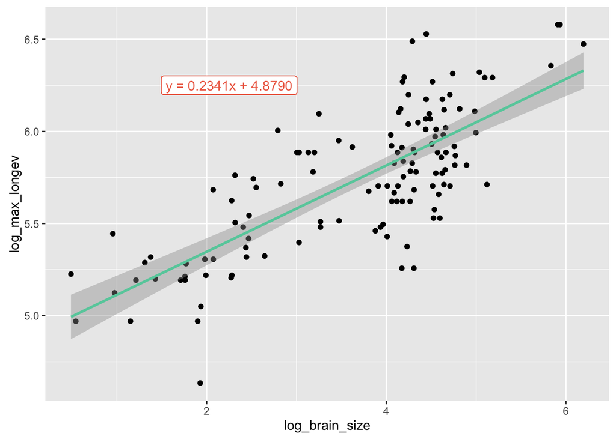

```r
#Scatterplot - log transformed
log_p <- ggplot(data=d,aes(x=log_brain_size, y=log_max_longev)) + geom_point() + geom_smooth(method="lm",formula=y~x,color="aquamarine3") #create scatterplot
log_p <- log_p + geom_label(x=2.25,y=6.25,label="y = 0.2341x + 4.8790",color="coral2") #add model equation
log_p
```

## Step 2: Identify and interpret the point estimate of the slope beta1, as well as the outcome of the test associated with the hypotheses H0: beta1 = 0; HA: beta1 ≠ 0. Also, find a 90 percent CI for the slope beta1 parameter.

```r
#From the linear models calculated in part 1, we see that beta1(regular) = 1.218 and beta1(log transformed) = 0.2341. For every gram/log_gram in brain size, the value of mean maximum longevity will increase by 1.218 months and 0.2341 log_months, for regular and log-transformed data respectively. In both cases, beta1 is not equal to 0 and is accompanied by an incredibly low p-value. We can thus reject the null hypothesis, which says that our predictor variable (brain size) has no effect on our response variable (maximum longevity).

#90% CI for beta1 - regular
confint(m,level=0.90)
```

```
##                    5 %      95 %
## (Intercept) 230.540738 267.36379
## brain_size    1.035571   1.40041
```

```r
#Shows that the slope (beta1) falls between 1.0356 and 1.4004 with 90% confidence

#90% CI for beta1 - log transformed
confint(log_m,level=0.90)
```

```
##                      5 %      95 %
## (Intercept)    4.7644934 4.9934084
## log_brain_size 0.2046396 0.2636595
```

```r
#Shows that the slope (beta1) for log transformed data falls between 0.2046 and 0.2636 with 90% confidence
```

## Step 3: Using your model, add lines for the 90 percent confidence and prediction interval bands on the plot and add a legend to differentiate between the lines.

```r
#Add predicted values to data frame - regular
ml_hat<-predict(m,newdata=data.frame(brain_size=d$Brain_Size_Species_Mean))
df<-data.frame(cbind(d$Brain_Size_Species_Mean,d$MaxLongevity_m,ml_hat))
names(df)<-c("x","y","yhat")
head(df) #make sure everything added correctly
```

```
##       x     y     yhat
## 1 58.02 276.0 319.6201
## 2    NA    NA       NA
## 3 52.84    NA 313.3109
## 4 52.63 243.6 313.0551
## 5 51.70    NA 311.9224
## 6 49.88 300.0 309.7056
```

```r
#Add predicted values to data frame - log transformed
log_ml_hat<-predict(log_m,newdata=data.frame(log_brain_size=log(d$Brain_Size_Species_Mean)))
log_ml_hat
```

[output not shown]

```r
log_df<-data.frame(cbind(log(d$Brain_Size_Species_Mean),log(d$MaxLongevity_m),log_ml_hat))
names(log_df)<-c("x","y","yhat")
head(log_df)
```

```
##          x        y     yhat
## 1 4.060788 5.620401 5.829783
## 2       NA       NA       NA
## 3 3.967268       NA 5.807885
## 4 3.963286 5.495528 5.806953
## 5 3.945458       NA 5.802778
## 6 3.909620 5.703782 5.794387
```

```r
#90% CI - regular
ci <- predict(m, newdata = data.frame(brain_size = d$Brain_Size_Species_Mean), interval = "confidence", level = 0.90)
head(ci)
```

```
##        fit      lwr      upr
## 1 319.6201 306.1354 333.1047
## 2       NA       NA       NA
## 3 313.3109 299.6449 326.9768
## 4 313.0551 299.3805 326.7297
## 5 311.9224 298.2081 325.6366
## 6 309.7056 295.9081 323.5032
```

```r
df<-cbind(df,ci) #add ci values to data frame
names(df)<-c("x","y","yhat","CIfit","CIlwr","CIupr")
head(df) #did it add the ci values and titles like I wanted? yes. good.
```

```
##       x     y     yhat    CIfit    CIlwr    CIupr
## 1 58.02 276.0 319.6201 319.6201 306.1354 333.1047
## 2    NA    NA       NA       NA       NA       NA
## 3 52.84    NA 313.3109 313.3109 299.6449 326.9768
## 4 52.63 243.6 313.0551 313.0551 299.3805 326.7297
## 5 51.70    NA 311.9224 311.9224 298.2081 325.6366
## 6 49.88 300.0 309.7056 309.7056 295.9081 323.5032
```

```r
#90% PI - regular
pi <- predict(m, newdata = data.frame(brain_size = d$Brain_Size_Species_Mean), interval = "prediction", level = 0.90)
head(pi)
```

```
##        fit      lwr      upr
## 1 319.6201 168.3750 470.8651
## 2       NA       NA       NA
## 3 313.3109 162.0496 464.5722
## 4 313.0551 161.7930 464.3172
## 5 311.9224 160.6567 463.1880
## 6 309.7056 158.4324 460.9789
```

```r
df <- cbind(df, pi)
names(df) <- c("x", "y", "yhat", "CIfit", "CIlwr", "CIupr", "PIfit", "PIlwr","PIupr")
head(df)
```

```
##       x     y     yhat    CIfit    CIlwr    CIupr    PIfit    PIlwr
## 1 58.02 276.0 319.6201 319.6201 306.1354 333.1047 319.6201 168.3750
## 2    NA    NA       NA       NA       NA       NA       NA       NA
## 3 52.84    NA 313.3109 313.3109 299.6449 326.9768 313.3109 162.0496
## 4 52.63 243.6 313.0551 313.0551 299.3805 326.7297 313.0551 161.7930
## 5 51.70    NA 311.9224 311.9224 298.2081 325.6366 311.9224 160.6567
## 6 49.88 300.0 309.7056 309.7056 295.9081 323.5032 309.7056 158.4324
##      PIupr
## 1 470.8651
## 2       NA
## 3 464.5722
## 4 464.3172
## 5 463.1880
## 6 460.9789
```

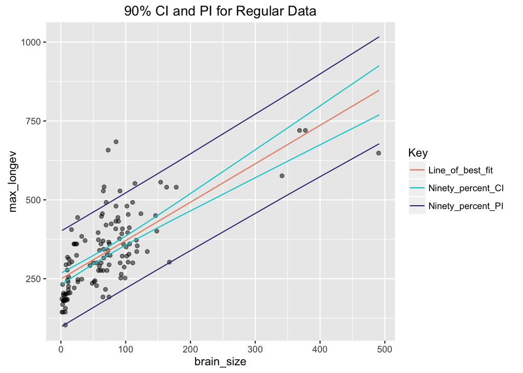

```r
#Plot 90% CI + PI - regular + hurray for stack overflow!
g <- ggplot(data = df, aes(x = brain_size, y = max_longev)) +
  geom_point(alpha = 1/2) +
  ggtitle("90% CI and PI for Regular Data") +
  geom_line(aes(x = x, y = CIfit, colour = "Line_of_best_fit")) +
  geom_line(aes(x = x, y = CIlwr, colour = "Ninety_percent_CI")) +
  geom_line(aes(x = x, y = CIupr, colour = "Ninety_percent_CI")) +
  geom_line(aes(x = x, y = PIfit, colour = "Line_of_best_fit")) +
  geom_line(aes(x = x, y = PIlwr, colour = "Ninety_percent_PI")) +
  geom_line(aes(x = x, y = PIupr, colour = "Ninety_percent_PI")) + scale_colour_manual(name="Key",values=c(Line_of_best_fit="darksalmon",
      Ninety_percent_CI="darkturquoise", Ninety_percent_PI="darkslateblue"))
g
```

```r
#ggplot only likes to make legends for things that have aesthetic mappings - I set "code names" for the colors and defined them manually for each attribute.

#90% CI - log transformed
log_ci <- predict(log_m,newdata=data.frame(log_brain_size=log(d$Brain_Size_Species_Mean)),interval="confidence", level = 0.90)
head(log_ci)
```

```
##        fit      lwr      upr
## 1 5.829783 5.791675 5.867891
## 2       NA       NA       NA
## 3 5.807885 5.770504 5.845267
## 4 5.806953 5.769598 5.844308
## 5 5.802778 5.765539 5.840018
## 6 5.794387 5.757357 5.831416
```

```r
log_df<-cbind(log_df,log_ci)
names(log_df)<-c("x","y","yhat","CIfit","CIlwr","CIupr")
head(log_df)
```

```
##          x        y     yhat    CIfit    CIlwr    CIupr
## 1 4.060788 5.620401 5.829783 5.829783 5.791675 5.867891
## 2       NA       NA       NA       NA       NA       NA
## 3 3.967268       NA 5.807885 5.807885 5.770504 5.845267
## 4 3.963286 5.495528 5.806953 5.806953 5.769598 5.844308
## 5 3.945458       NA 5.802778 5.802778 5.765539 5.840018
## 6 3.909620 5.703782 5.794387 5.794387 5.757357 5.831416
```

```r
#90% PI - log transformed
log_pi <- predict(log_m, newdata=data.frame(log_brain_size=log(d$Brain_Size_Species_Mean)),interval="prediction", level = 0.90)
head(log_pi)
```

```
##        fit      lwr      upr
## 1 5.829783 5.416322 6.243243
## 2       NA       NA       NA
## 3 5.807885 5.394491 6.221279
## 4 5.806953 5.393561 6.220344
## 5 5.802778 5.389397 6.216159
## 6 5.794387 5.381024 6.207749
```

```r
log_df <- cbind(log_df, log_pi)
names(log_df) <- c("x", "y", "yhat", "CIfit", "CIlwr", "CIupr", "PIfit", "PIlwr","PIupr")
head(log_df)
```

```
##          x        y     yhat    CIfit    CIlwr    CIupr    PIfit    PIlwr
## 1 4.060788 5.620401 5.829783 5.829783 5.791675 5.867891 5.829783 5.416322
## 2       NA       NA       NA       NA       NA       NA       NA       NA
## 3 3.967268       NA 5.807885 5.807885 5.770504 5.845267 5.807885 5.394491
## 4 3.963286 5.495528 5.806953 5.806953 5.769598 5.844308 5.806953 5.393561
## 5 3.945458       NA 5.802778 5.802778 5.765539 5.840018 5.802778 5.389397
## 6 3.909620 5.703782 5.794387 5.794387 5.757357 5.831416 5.794387 5.381024
##      PIupr
## 1 6.243243
## 2       NA
## 3 6.221279
## 4 6.220344
## 5 6.216159
## 6 6.207749
```

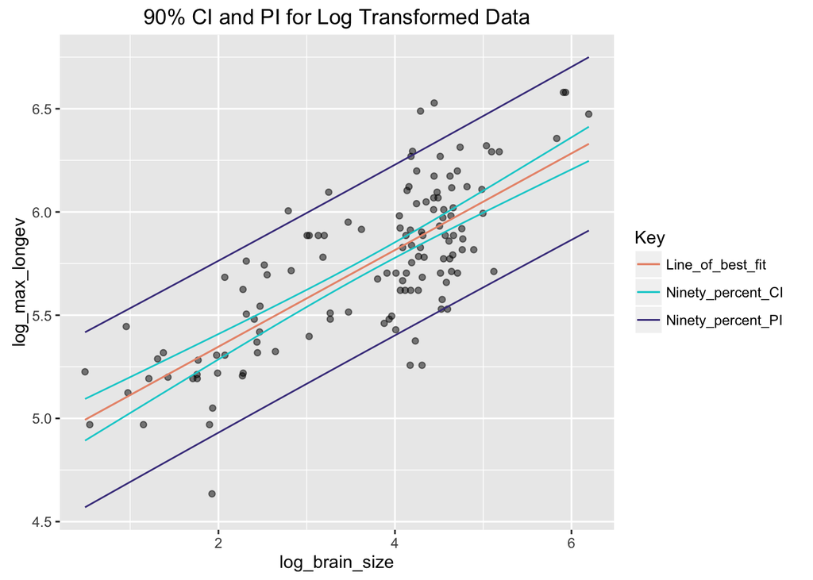

```r
#Plot 90% CI + PI - log transformed
g <- ggplot(data = log_df, aes(x = log_brain_size, y = log_max_longev)) +
  geom_point(alpha = 1/2) +
  ggtitle("90% CI and PI for Log Transformed Data") +
  geom_line(aes(x = x, y = CIfit, colour = "Line_of_best_fit")) +
  geom_line(aes(x = x, y = CIlwr, colour = "Ninety_percent_CI")) +
  geom_line(aes(x = x, y = CIupr, colour = "Ninety_percent_CI")) +
  geom_line(aes(x = x, y = PIfit, colour = "Line_of_best_fit")) +
  geom_line(aes(x = x, y = PIlwr, colour = "Ninety_percent_PI")) +
  geom_line(aes(x = x, y = PIupr, colour = "Ninety_percent_PI")) + scale_colour_manual(name="Key",values=c(Line_of_best_fit="darksalmon",
      Ninety_percent_CI="darkturquoise", Ninety_percent_PI="darkslateblue"))
g
```

## Step 4: Produce a point estimate and associated 90 percent PI for the longevity of a species whose brain weight is 800 gm. Do you trust the model to predict observations accurately for this value of the explanatory variable? Why or why not?

```r
#Point estimate - regular
pi <- predict(m, newdata = data.frame(brain_size = 800), interval = "prediction", level = 0.90)
pi
```

```
##        fit      lwr      upr
## 1 1223.345 1021.805 1424.884
```

```r
#Point estimate - log transformed
log_pi <- predict(log_m, newdata = data.frame(log_brain_size = log(800)), interval = "prediction", level = 0.90)
log_pi
```

```
##       fit      lwr      upr
## 1 6.44415 6.021424 6.866876
```

Regular data: brain size of 800 –> maximum longevity 1223.345, PIlwr: 1021.805, PIupr: 1424.884 Log transformed data: brain size of log(800) –> maximum longevity 6.444, PIlwr: 6.021 PIupr: 6.867 I would not trust the model to predict an accurate observation at 800g. This would require an extrapolation that was well beyond our current data-set, which would lessen the accuracy of our linear model.

## Step 5: Looking at your two models, which do you think is better? Why?

I think the log transformed model is better. The regular data is heavily skewed, and the log transformation “normalizes” our data by bringing extreme data points closer to a measure of centrality. This allows us to more clearly see the relationship (or lack thereof) between our variables.